# Laboratoire 2 : Arbres de décision, Bayes naïf et KNN

# Question 1

Avant tout, les primitives des galaxies extraites au laboratoire 1 ont été combinées à celles données pour le laboratoire. Pour ce faire, un script a été programmé pour extraire les quatre primitives du laboratoire 1 des plus de 16 000 images. Ce script a enregistré les primitives dans un fichier csv et ce, dans le même ordre que le fichier contenant les primitives données. Ensuite, le contenu du fichier des primitives du laboratoire 1 a manuellement été inséré dans le fichier des primitives données.  
En ce qui concerne la lecture des données avant l'entraînement, le contenu de chacun des fichiers de primitives a été chargé dans deux listes; une pour les primitives et une pour la classe des observations. Ainsi, à la suite de la lecture des fichiers contenant les primitives de chaque ensemble, les listes suivantes ont été chargées :

| Liste | Contenu | Forme du vecteur |
| --- | --- | --- |
| gala_features | Primitives des galaxies | (16908, 79) |
| gala_labels | Classes des observations des galaxies | (16908,) |
| pourriel_features | Primitives des courriels | (2760, 57) |
| pourriel_labels | Classes des observations des courriels | (2760,) |

Les listes pour les galaxies contiennent 8776 galaxies spirales et 8132 galaxies smooth. Quant aux listes pour les courriels, elles contiennent 1105 observations classées comme pourriel et 1655 observations qui ne sont pas des pourriels.  
C’est important de noter que le type des valeurs des classes dans ces ensembles de données a été changé afin de faciliter l’interprétation des prédictions. De ce fait, dans les fichiers les classes des galaxies sont dénotées par les valeurs numériques 0 et 1. Lorsque ces données sont lues, les valeurs des classes sont changées pour les chaînes de caractère « spiral » et « smooth ». Par conséquent, les données contenues dans gala_labels et pourriel_labels doivent être encodées avec un LabelEncoder. Cet encodeur donne à nouveau une valeur numérique à chaque classe. De ce fait, lorsqu’une prédiction est effectuée, le LabelEncoder peut être utilisé pour obtenir la représentation en chaîne de caractères à partir de la prédiction sous forme numérique.

# 1 - Recherche des meilleurs hyperparamètres

### Arbre de décision: pourriels avec holdout 80/20

Paramètres évalués:

- max_depth ∈ {None, 3, 5, 10, 30, 50}

```
* Best f1 score:  0.9083012091338053
* Best accuracy:  0.9094202898550725
* Best params. :  {'max_depth': 10}
```

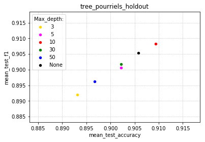

|  | Params | Accuracy-Rank | Accuracy-Test | F1-Rank | F1-Test |
| --- | --- | --- | --- | --- | --- |
| 0 | None | 2 | 0.905797101449275 | 2 | 0.905407704547197 |
| 1 | 3 | 6 | 0.893115942028985 | 6 | 0.8920933539518 |
| 2 | 5 | 3 | 0.902173913043478 | 4 | 0.900611666121673 |
| 3 | 10 | 1 | 0.909420289855073 | 1 | 0.908301209133805 |
| 4 | 30 | 3 | 0.902173913043478 | 3 | 0.901769539337474 |
| 5 | 50 | 5 | 0.896739130434783 | 5 | 0.896265301585907 |

```python
title = 'tree_pourriels_holdout'
results[title] = mt.pipelined_search(
    x=pourriel_features,
    y=encoded_pourriel_lbs,
    estimator=DecisionTreeClassifier(),
    parameters={
        'max_depth': [None,3,5,10,30,50]
    },
    test_size=TEST_SIZE
)

# Affiche le meilleur résultat, le graphique et le tableau des resultats
dr.display_score(results,title,True,False)
dr.tree_plot(results,title)
dr.results_table(results,title,'clf__max_depth')
```

### Arbre de décision: galaxies avec holdout 80/20

Paramètres évalués:

- max_depth ∈ {None, 3, 5, 10, 30, 50}

```
* Best f1 score:  0.9183602526077621
* Best accuracy:  0.9183914843287996
* Best params. :  {'max_depth': 10}
```

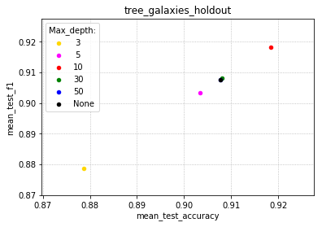

|  | Params | Accuracy-Rank | Accuracy-Test | F1-Rank | F1-Test |
| --- | --- | --- | --- | --- | --- |
| 0 | None | 3 | 0.907746895328208 | 4 | 0.907744795183141 |
| 1 | 3 | 6 | 0.878769958604376 | 6 | 0.878574111289296 |
| 2 | 5 | 5 | 0.903311649911295 | 5 | 0.903316855584277 |
| 3 | 10 | 1 | 0.9183914843288 | 1 | 0.918360252607762 |
| 4 | 30 | 2 | 0.908042578356002 | 2 | 0.908041539724231 |
| 5 | 50 | 3 | 0.907746895328208 | 3 | 0.907752807000812 |

```python
title = 'tree_galaxies_holdout'
results[title] = mt.pipelined_search(
    x=gala_features,
    y=encoded_gala_lbs,
    estimator=DecisionTreeClassifier(),
    parameters={
        'max_depth': [None,3,5,10,30,50],
    },
    test_size=TEST_SIZE
)

# Affiche le meilleur résultat, le graphique et le tableau des resultats
dr.display_score(results,title,True,False)
dr.tree_plot(results,title)
dr.results_table(results,title,'clf__max_depth')
```

### Bayes naïf gaussien: pourriels avec holdout 80/20

```python
title = 'bayes_gaussian_pourriels_holdout'
results[title] = mt.pipelined_search(
    x=pourriel_features,
    y=encoded_pourriel_lbs,
    estimator=GaussianNB(),
    test_size=TEST_SIZE
)

# Affiche le meilleur résultat et la graphique
dr.display_score(results,title,True,False)
```

```
* Best f1 score:  0.8018771846002967
* Best accuracy:  0.8007246376811594
* Best params. :  {}
```

### Bayes naïf gaussien: galaxies avec holdout 80/20

```python
title = 'bayes_gaussian_galaxies_holdout'
results[title] = mt.pipelined_search(
    x=gala_features,
    y=encoded_gala_lbs,
    estimator=GaussianNB(),
    test_size=TEST_SIZE
)

# Affiche le meilleur résultat et le graphique
dr.display_score(results,title,True,False)
```

```
* Best f1 score:  0.8037068645517003
* Best accuracy:  0.8057362507392075
* Best params. :  {}
```

### Bayes naïf multinominal: pourriels avec holdout 80/20

```python
# Puisqu'on ne fait pas bayes Multinominal (pourriels) sans prétraitement,
# on ajoute une ligne vide pour le tableau final (comparaison).
add(['bayes_multinominal_pourriels_nan',np.nan,1,1])
addCompare(['bayes_multinominal_pourriels_holdout',np.nan,1,1])
```

### Bayes naïf multinominal: galaxies avec holdout 80/20

```python
# Puisqu'on ne fait pas bayes Multinominal (galaxy) sans prétraitement,
# on ajoute une ligne vide pour le tableau final (comparaison).
add(['bayes_multinominal_galaxies_nan',np.nan,1,1])
addCompare(['bayes_multinominal_galaxies_holdout',np.nan,1,1])
```

### KNN: pourriels avec holdout 80/20

Paramètres testés:

- k ∀ [1, 50]
- weights ∈ {uniform, distance}

```
* Best f1 score:  0.8024612669296631
* Best accuracy:  0.802536231884058
* Best params. :  {'n_neighbors': 20, 'weights': 'distance'}
```

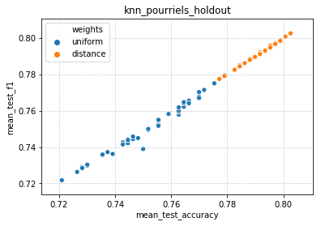

```
* Les 5 meilleurs résultats (Accuracy-Test & F1-Test)
```

|  | Params | Accuracy-Rank | Accuracy-Test | F1-Rank | F1-Test |
| --- | --- | --- | --- | --- | --- |
| 0 | distance | 2 | 0.800724637681159 | 2 | 0.800724637681159 |
| 1 | distance | 1 | 0.802536231884058 | 1 | 0.802461266929663 |
| 2 | distance | 3 | 0.798913043478261 | 3 | 0.798347126884988 |
| 3 | distance | 3 | 0.798913043478261 | 5 | 0.798171796466855 |
| 4 | distance | 3 | 0.798913043478261 | 5 | 0.798171796466855 |
| 5 | distance | 3 | 0.798913043478261 | 3 | 0.798347126884988 |

```python
title = 'knn_pourriels_holdout'
results[title] = mt.pipelined_search(
    x=pourriel_features,
    y=encoded_pourriel_lbs,
    estimator=KNeighborsClassifier(),
    parameters={
        'n_neighbors': range(1, 51),
        'weights': ['uniform', 'distance']
    },
    test_size=TEST_SIZE
)

# Affiche le meilleur résultat et le graphique
dr.display_score(results,title,True,False)
dr.knn_plot(results,title)

# Tableau des TOP 5 resultats (Rank)
print("*************************************************************")
print("* Les 5 meilleurs résultats (Accuracy-Test & F1-Test)")
print("*************************************************************")
dr.results_table(results,title,'clf__weights')
```

### KNN: galaxies avec holdout 80/20

Paramètres évalués:

- k ∀ [1, 50]
- weights ∈ {uniform, distance}

```
* Best f1 score:  0.6854926239089605
* Best accuracy:  0.6853932584269663
* Best params. :  {'n_neighbors': 48, 'weights': 'uniform'}
```

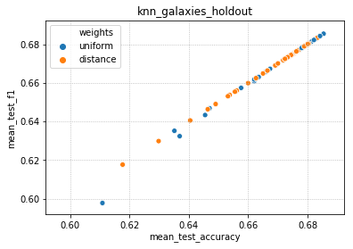

```
* Les 5 meilleurs résultats (Accuracy-Test & F1-Test)
```

|  | Params | Accuracy-Rank | Accuracy-Test | F1-Rank | F1-Test |
| --- | --- | --- | --- | --- | --- |
| 0 | uniform | 6 | 0.681845062093436 | 6 | 0.681937256226347 |
| 1 | uniform | 4 | 0.682732111176818 | 4 | 0.682825573499453 |
| 2 | uniform | 1 | 0.685393258426966 | 1 | 0.68549262390896 |
| 3 | distance | 3 | 0.683323477232407 | 3 | 0.683413665112356 |
| 4 | uniform | 2 | 0.684210526315789 | 2 | 0.684307775785821 |
| 5 | uniform | 5 | 0.68214074512123 | 5 | 0.682249901049218 |

```python
title = 'knn_galaxies_holdout'
results[title] = mt.pipelined_search(
    x=gala_features,
    y=encoded_gala_lbs,
    estimator=KNeighborsClassifier(),
    parameters={
        'n_neighbors': range(1, 51),
        'weights': ['uniform', 'distance']
    },
    test_size=TEST_SIZE
)

# Affiche le meilleur résultat et le graphique
dr.display_score(results,title,True,False)
dr.knn_plot(results,title)

# Tableau des TOP 5 resultats
print("*************************************************************")
print("* Les 5 meilleurs résultats (Accuracy-Test & F1-Test)")
print("*************************************************************")
dr.results_table(results,title,'clf__weights')
```

### Résultats des meilleurs algorithme sans pré-traitement

```python
# Affiche le tableau des meilleurs résultats de prétraitements
dr.best_results_table()
```

|  | Algorithmes | Paramètres | F1 Score | Accuracy |
| --- | --- | --- | --- | --- |
| 0 | tree_pourriels_holdout | {'max_depth': 10} | 0.908301209133805 | 0.909420289855073 |
| 1 | tree_galaxies_holdout | {'max_depth': 10} | 0.918360252607762 | 0.9183914843288 |
| 2 | bayes_gaussian_pourriels_holdout | {} | 0.801877184600297 | 0.800724637681159 |
| 3 | bayes_gaussian_galaxies_holdout | {} | 0.8037068645517 | 0.805736250739208 |
| 4 | bayes_multinominal_pourriels_nan | nan | 1 | 1 |
| 5 | bayes_multinominal_galaxies_nan | nan | 1 | 1 |
| 6 | knn_pourriels_holdout | {'n_neighbors': 20, 'weights': 'distance'} | 0.802461266929663 | 0.802536231884058 |
| 7 | knn_galaxies_holdout | {'n_neighbors': 48, 'weights': 'uniform'} | 0.68549262390896 | 0.685393258426966 |

# 2 - Recherche des meilleurs prétraitements

### Arbre de décision: pourriels avec holdout 80/20

Paramètres utilisé:

- max_depth = Choisi en fonction des expériences précédentes (voir le résultat plus bas)

Prétraitements appliqués :

- MinMaxScaler

```python
# Remet à zéro les résultats pour le tableau des meilleurs prétraitements
reset()
```

```python
max_depth = results['tree_pourriels_holdout']['best_params']['max_depth']

title = 'tree_MinMaxScaler_pourriels_holdout'
results[title] = mt.pipelined_search(
    x=pourriel_features,
    y=encoded_pourriel_lbs,
    estimator=DecisionTreeClassifier(),
    parameters={
        'max_depth': [max_depth]
    },
    test_size=TEST_SIZE,
    transformers=[("minMaxScaler",MinMaxScaler())]
)

# Affiche le meilleur résultat et le graphique
dr.display_score(results,title,False,True)
```

```
* Best f1 score:  0.9092786950142518
* Best accuracy:  0.9094202898550725
* Best params. :  {'max_depth': 10}
```

### Arbre de décision: pourriels avec holdout 80/20

Paramètres utilisé:

- max_depth = Choisi en fonction des expériences précédentes (voir le résultat plus bas)

Prétraitements appliqués :

- KBinsDiscretizer

```python
max_depth = results['tree_pourriels_holdout']['best_params']['max_depth']

title = 'tree_KBinsDiscretizer_pourriels_holdout'
results[title] = mt.pipelined_search(
    x=pourriel_features,
    y=encoded_pourriel_lbs,
    estimator=DecisionTreeClassifier(),
    parameters={
        'max_depth': [max_depth]
    },
    test_size=TEST_SIZE,
    transformers=[("kbinsdiscretizer",KBinsDiscretizer(n_bins=3, strategy="kmeans"))]
)

# Affiche le meilleur résultat et le graphique
dr.display_score(results,title,False,False)
```

```
* Best f1 score:  0.8669712809790295
* Best accuracy:  0.8695652173913043
* Best params. :  {'max_depth': 10}
```

### Arbre de décision: galaxies avec holdout 80/20

Paramètres utilisé:

- max_depth = Choisi en fonction des expériences précédentes (voir le résultat plus bas)

Prétraitements appliqués :

- MinMaxScaler

```python
max_depth = results['tree_galaxies_holdout']['best_params']['max_depth']

title = 'tree_MinMaxScaler_galaxies_holdout'
results[title] = mt.pipelined_search(
    x=gala_features,
    y=encoded_gala_lbs,
    estimator=DecisionTreeClassifier(),
    parameters={
        'max_depth': [max_depth],
    },
    test_size=TEST_SIZE,
    transformers=[("minMaxScaler",MinMaxScaler())]
)

# Affiche le meilleur résultat et le graphique
dr.display_score(results,title,False,True)
```

```
* Best f1 score:  0.9124900501425922
* Best accuracy:  0.9124778237729154
* Best params. :  {'max_depth': 10}
```

### Bayes naïf gaussian: pourriels avec holdout 80/20

```python
# Puisqu'on ne fait pas bayes Gaussian (pourriels) avec prétraitement,
# on ajoute une ligne vide pour le tableau final (comparaison).
add(['bayes_gaussian_pourriels_nan',np.nan,1,1])
addPretraitement(['aucun',1,1])
```

### Bayes naïf gaussian: galaxies avec holdout 80/20

```python
# Puisqu'on ne fait pas bayes Gaussian (galaxy) avec prétraitement,
# on ajoute une ligne vide pour le tableau final (comparaison).
add(['bayes_gaussian_galaxies_nan',np.nan,1,1])
addPretraitement(['aucun2',1,1])
```

### Bayes naïf multinomial: pourriels avec holdout 80/20

Prétraitements appliqués :

- MinMaxScaler

```python
title = 'bayes_multinominal_MinMaxScaler_pourriels_holdout'
results[title] = mt.pipelined_search(
    x=pourriel_features,
    y=encoded_pourriel_lbs,
    estimator=MultinomialNB(),
    test_size=TEST_SIZE,
    transformers=[("minMaxScaler",MinMaxScaler())]
)

# Affiche le meilleur résultat et la graphique
dr.display_score(results,title,False,True)
```

```
* Best f1 score:  0.910982065021301
* Best accuracy:  0.9112318840579711
* Best params. :  {}
```

### Bayes naïf multinomial: pourriels avec holdout 80/20

Prétraitements appliqués :

- KBinsDiscretizer

```python
title = 'bayes_multinominal_KBinsDiscretizer_pourriels_holdout'
results[title] = mt.pipelined_search(
    x=pourriel_features,
    y=encoded_pourriel_lbs,
    estimator=MultinomialNB(),
    test_size=TEST_SIZE,
    transformers=[("kbinsdiscretizer",KBinsDiscretizer(n_bins=3, strategy="kmeans"))]
)

# Affiche le meilleur résultat et la graphique
dr.display_score(results,title,False,False)
```

```
* Best f1 score:  0.8725593800322062
* Best accuracy:  0.8731884057971014
* Best params. :  {}
```

### Bayes naïf multinomial: galaxies avec holdout 80/20

Prétraitements appliqués :

- MinMaxScaler

```python
title = 'bayes_multinominal_MinMaxScaler_galaxies_holdout'
results[title] = mt.pipelined_search(
    x=gala_features,
    y=encoded_gala_lbs,
    estimator=MultinomialNB(),
    test_size=TEST_SIZE,
    transformers=[("minMaxScaler",MinMaxScaler())]
)

# Affiche le meilleur résultat et la graphique
dr.display_score(results,title,False,True)
```

```
* Best f1 score:  0.8095010454298314
* Best accuracy:  0.8095801301005322
* Best params. :  {}
```

### KNN: pourriels avec holdout 80/20

Paramètres utilisé:

- k = Choisi en fonction des expériences précédentes (voir le résultat plus bas)
- weights = Choisi en fonction des expériences précédentes (voir le résultat plus bas)

Prétraitements appliqués :

- MinMaxScaler

```python
n_neighbors = results['knn_pourriels_holdout']['best_params']['n_neighbors']
weights = results['knn_pourriels_holdout']['best_params']['weights']

title = 'knn_MinMaxScaler_pourriels_holdout'
results[title] = mt.pipelined_search(
    x=pourriel_features,
    y=encoded_pourriel_lbs,
    estimator=KNeighborsClassifier(),
    parameters={
        'n_neighbors': [n_neighbors],
        'weights': [weights]
    },
    test_size=TEST_SIZE,
    transformers=[("minMaxScaler",MinMaxScaler())]
)

# Affiche le meilleur résultat et le graphique
dr.display_score(results,title,False,True)
```

```
* Best f1 score:  0.906917461740411
* Best accuracy:  0.907608695652174
* Best params. :  {'n_neighbors': 20, 'weights': 'distance'}
```

### KNN: pourriels avec holdout 80/20

Paramètres utilisé:

- k = Choisi en fonction des expériences précédentes (voir le résultat plus bas)
- weights = Choisi en fonction des expériences précédentes (voir le résultat plus bas)

Prétraitements appliqués :

- KBinsDiscretizer

```python
n_neighbors = results['knn_pourriels_holdout']['best_params']['n_neighbors']
weights = results['knn_pourriels_holdout']['best_params']['weights']

title = 'knn_KBinsDiscretizer_pourriels_holdout'
results[title] = mt.pipelined_search(
    x=pourriel_features,
    y=encoded_pourriel_lbs,
    estimator=KNeighborsClassifier(),
    parameters={
        'n_neighbors': [n_neighbors],
        'weights': [weights]
    },
    test_size=TEST_SIZE,
    transformers=[("kbinsdiscretizer",KBinsDiscretizer(n_bins=3, strategy="kmeans"))]
)

# Affiche le meilleur résultat et le graphique
dr.display_score(results,title,False,False)
```

```
* Best f1 score:  0.8393346056738433
* Best accuracy:  0.8460144927536232
* Best params. :  {'n_neighbors': 20, 'weights': 'distance'}
```

### KNN: galaxies avec holdout 80/20

Paramètres utilisé:

- k = Choisi en fonction des expériences précédentes (voir le résultat plus bas)
- weights = Choisi en fonction des expériences précédentes (voir le résultat plus bas)

Prétraitements appliqués :

- MinMaxScaler

```python
n_neighbors = results['knn_galaxies_holdout']['best_params']['n_neighbors']
weights = results['knn_galaxies_holdout']['best_params']['weights']

title = 'knn_MinMaxScaler_galaxies_holdout'
results[title] = mt.pipelined_search(
    x=gala_features,
    y=encoded_gala_lbs,
    estimator=KNeighborsClassifier(),
    parameters={
        'n_neighbors': [n_neighbors],
        'weights': [weights]
    },
    test_size=TEST_SIZE,
    transformers=[("minMaxScaler",MinMaxScaler())]
)

# Affiche le meilleur résultat et le graphique
dr.display_score(results,title,False,True)
```

```
* Best f1 score:  0.8992081992216007
* Best accuracy:  0.8991720875221763
* Best params. :  {'n_neighbors': 48, 'weights': 'uniform'}
```

### Résultats des meilleurs prétraitements

```python
# Affiche le tableau des meilleurs résultats de prétraitements
dr.best_results_table()
```

|  | Algorithmes | Paramètres | F1 Score | Accuracy |
| --- | --- | --- | --- | --- |
| 0 | tree_MinMaxScaler_pourriels_holdout | {'max_depth': 10} | 0.909278695014252 | 0.909420289855073 |
| 1 | tree_KBinsDiscretizer_pourriels_holdout | {'max_depth': 10} | 0.86697128097903 | 0.869565217391304 |
| 2 | tree_MinMaxScaler_galaxies_holdout | {'max_depth': 10} | 0.912490050142592 | 0.912477823772915 |
| 3 | bayes_gaussian_pourriels_nan | nan | 1 | 1 |
| 4 | bayes_gaussian_galaxies_nan | nan | 1 | 1 |
| 5 | bayes_multinominal_MinMaxScaler_pourriels_holdout | {} | 0.910982065021301 | 0.911231884057971 |
| 6 | bayes_multinominal_KBinsDiscretizer_pourriels_holdout | {} | 0.872559380032206 | 0.873188405797101 |
| 7 | bayes_multinominal_MinMaxScaler_galaxies_holdout | {} | 0.809501045429831 | 0.809580130100532 |
| 8 | knn_MinMaxScaler_pourriels_holdout | {'n_neighbors': 20, 'weights': 'distance'} | 0.906917461740411 | 0.907608695652174 |
| 9 | knn_KBinsDiscretizer_pourriels_holdout | {'n_neighbors': 20, 'weights': 'distance'} | 0.839334605673843 | 0.846014492753623 |
| 10 | knn_MinMaxScaler_galaxies_holdout | {'n_neighbors': 48, 'weights': 'uniform'} | 0.899208199221601 | 0.899172087522176 |

# 3 - Entrainement des algorithmes les plus prometteurs avec validation K-folds

### Arbre de décision: pourriels avec K-folds | k=10

Paramètres utilisé:

- max_depth = Choisi en fonction des expériences précédentes (voir le résultat plus bas)

Prétraitements appliqués :

- Choisi en fonction des expériences précédentes (voir le résultat plus bas)

```python
# Remet à zéro les résultats pour le tableau des algorithmes les plus prometteurs.
reset()
```

```python
max_depth = results['tree_pourriels_holdout']['best_params']['max_depth']

transformers = None

no_pre_f1 = results['tree_pourriels_holdout']['best_f1_score']
scaler_f1 = results['tree_MinMaxScaler_pourriels_holdout']['best_f1_score']
kbin_f1 = results['tree_KBinsDiscretizer_pourriels_holdout']['best_f1_score']

if no_pre_f1 < scaler_f1 and scaler_f1 < kbin_f1:
    transformers = [("kbinsdiscretizer",KBinsDiscretizer(n_bins=3, strategy="kmeans"))]
    print('Prétraitement : KBinsDiscretizer')
elif no_pre_f1 < kbin_f1 and kbin_f1 < scaler_f1:
    transformers = [("minMaxScaler",MinMaxScaler())]
    print('Prétraitement : minMaxScaler')
else:
    print('Prétraitement : aucun')

title = 'tree_pourriels_kfold'
results[title] = mt.pipelined_search(
    x=pourriel_features,
    y=encoded_pourriel_lbs,
    estimator=DecisionTreeClassifier(),
    parameters={
        'max_depth': [max_depth]
    },
    transformers=transformers
)

# Affiche le meilleur résultat et le graphique
dr.display_score(results,title,True,False)
```

```
Prétraitement : aucun
* Best f1 score:  0.9142058293079393
* Best accuracy:  0.9144927536231884
* Best params. :  {'max_depth': 10}
```

### Arbre de décision: galaxies avec K-folds | k=10

Paramètres utilisé:

- max_depth = Choisi en fonction des expériences précédentes (voir le résultat plus bas)

Prétraitements appliqués :

- Choisi en fonction des expériences précédentes (voir le résultat plus bas)

```python
max_depth = results['tree_galaxies_holdout']['best_params']['max_depth']
transformers = None

no_pre_f1 = results['tree_galaxies_holdout']['best_f1_score']
scaler_f1 = results['tree_MinMaxScaler_galaxies_holdout']['best_f1_score']

if no_pre_f1 < scaler_f1:
    transformers = [("minMaxScaler",MinMaxScaler())]
    print('Prétraitement : minMaxScaler')
else:
    print('Prétraitement : aucun')

title = 'tree_galaxies_kfold'
results[title] = mt.pipelined_search(
    x=gala_features,
    y=encoded_gala_lbs,
    estimator=DecisionTreeClassifier(),
    parameters={
        'max_depth': [max_depth],
    },
    transformers=transformers
)

# Affiche le meilleur résultat et le graphique
dr.display_score(results,title,True,False)
```

```
Prétraitement : aucun
* Best f1 score:  0.9134004232809657
* Best accuracy:  0.9134137686302342
* Best params. :  {'max_depth': 10}
```

### Bayes naïf gaussien: pourriels avec K-folds | k=10

```python
title = 'bayes_gaussian_pourriels_kfolds'
results[title] = mt.pipelined_search(
    x=pourriel_features,
    y=encoded_pourriel_lbs,
    estimator=GaussianNB()
)

# Affiche le meilleur résultat et la graphique
dr.display_score(results,title,True,False)
```

```
* Best f1 score:  0.8139573017043958
* Best accuracy:  0.8126811594202898
* Best params. :  {}
```

### Bayes naïf gaussien: galaxies avec K-folds | k=10

```python
title = 'bayes_gaussian_galaxies_kfolds'
results[title] = mt.pipelined_search(
    x=gala_features,
    y=encoded_gala_lbs,
    estimator=GaussianNB()
)

# Affiche le meilleur résultat et la graphique
dr.display_score(results,title,True,False)
```

```
* Best f1 score:  0.8026851815449322
* Best accuracy:  0.8047669742133902
* Best params. :  {}
```

### Bayes naïf multinomial: pourriels avec K-folds | k=10

Prétraitements appliqués :

- Choisi en fonction des expériences précédentes (voir le résultat plus bas)

```python
transformers = None
scaler_f1 = results['bayes_multinominal_MinMaxScaler_pourriels_holdout']['best_f1_score']
kbin_f1 = results['bayes_multinominal_KBinsDiscretizer_pourriels_holdout']['best_f1_score']

if scaler_f1 < kbin_f1:
    transformers = [("kbinsdiscretizer",KBinsDiscretizer(n_bins=3, strategy="kmeans"))]
    print('Prétraitement : KBinsDiscretizer')
else:
    transformers = [("minMaxScaler",MinMaxScaler())]
    print('Prétraitement : MinMaxScaler')

title = 'bayes_multinominal_pourriels_kfolds'
results[title] = mt.pipelined_search(
    x=pourriel_features,
    y=encoded_pourriel_lbs,
    estimator=MultinomialNB(),
    transformers=transformers
)

# Affiche le meilleur résultat et la graphique
dr.display_score(results,title,True,False)
```

```
Prétraitement : MinMaxScaler
* Best f1 score:  0.900368426280921
* Best accuracy:  0.9018115942028986
* Best params. :  {}
```

### Bayes naïf multinomial: galaxies avec K-folds | k=10

Prétraitements appliqués :

- MinMaxScaler

```python
title = 'bayes_multinominal_galaxies_kfolds'
results[title] = mt.pipelined_search(
    x=gala_features,
    y=encoded_gala_lbs,
    estimator=MultinomialNB(),
    transformers=[("minMaxScaler",MinMaxScaler())]
)

# Affiche le meilleur résultat et la graphique
dr.display_score(results,title,True,False)
```

```
* Best f1 score:  0.8028300129748065
* Best accuracy:  0.8029335225928554
* Best params. :  {}
```

### KNN: pourriels avec K-folds | k=10

```python
n_neighbors = results['knn_pourriels_holdout']['best_params']['n_neighbors']
weights = results['knn_pourriels_holdout']['best_params']['weights']

transformers = None
no_pre_f1 = results['knn_pourriels_holdout']['best_f1_score']
scaler_f1 = results['knn_MinMaxScaler_pourriels_holdout']['best_f1_score']
kbin_f1 = results['knn_KBinsDiscretizer_pourriels_holdout']['best_f1_score']


if no_pre_f1 < scaler_f1 and scaler_f1 < kbin_f1:
    transformers = [("kbinsdiscretizer",KBinsDiscretizer(n_bins=3, strategy="kmeans"))]
    print('Prétraitement : KBinsDiscretizer')
elif no_pre_f1 < kbin_f1 and kbin_f1 < scaler_f1:
    transformers = [("minMaxScaler",MinMaxScaler())]
    print('Prétraitement : minMaxScaler')
else:
    print('Prétraitement : aucun')

title = 'knn_pourriels_kfolds'
results[title] = mt.pipelined_search(
    x=pourriel_features,
    y=encoded_pourriel_lbs,
    estimator=KNeighborsClassifier(),
    parameters={
        'n_neighbors': [n_neighbors],
        'weights': [weights]
    },
    transformers=transformers
)

# Affiche le meilleur résultat, le graphique
dr.display_score(results,title,True,False)
```

```
Prétraitement : minMaxScaler
* Best f1 score:  0.8986905775289209
* Best accuracy:  0.8996376811594203
* Best params. :  {'n_neighbors': 20, 'weights': 'distance'}
```